# 072tasks

## Задание 1. Восстановление модели нелинейного маятника по фазовой траектории

Динамика нелинейного математического маятника с линейным вязким трением описывается дифференциальным уравнением: \begin{equation*} \ddot{x} + \gamma \dot{x} + \omega_0^2 \sin(x) = F(t), \quad x(0) = 0, \quad \dot{x}(0) = 0, \end{equation*} где $\gamma > 0$ и $\omega_0 > 0$ - неизвестные постоянные параметры системы, а $F(t)$ - гладкое внешнее воздействие класса $C^{\omega}(\mathbb{R})$.

### Известные свойства эталонного режима:

- В течение первых $10$ секунд маятник остаётся в состоянии, близком к покою ($|x(t)| < 10^{-4}$ рад).
- При прохождении верхней неустойчивой точки $x = \pi$ траектория проходит вблизи сепаратрисы: $\dot{x} \in (0, 10^{-3})$ рад/с.
- На интервале $t \in [25, 75]$ с внешнее воздействие практически отсутствует ($|F(t)| < 10^{-8}$), и система совершает свободные затухающие колебания вокруг положения равновесия $x = 2\pi$.
- Функция $F(t)$ задаётся одной элементарной формулой, содержащей не более трёх числовых констант (не считая математических констант $\pi$ и $e$).

### Задание:

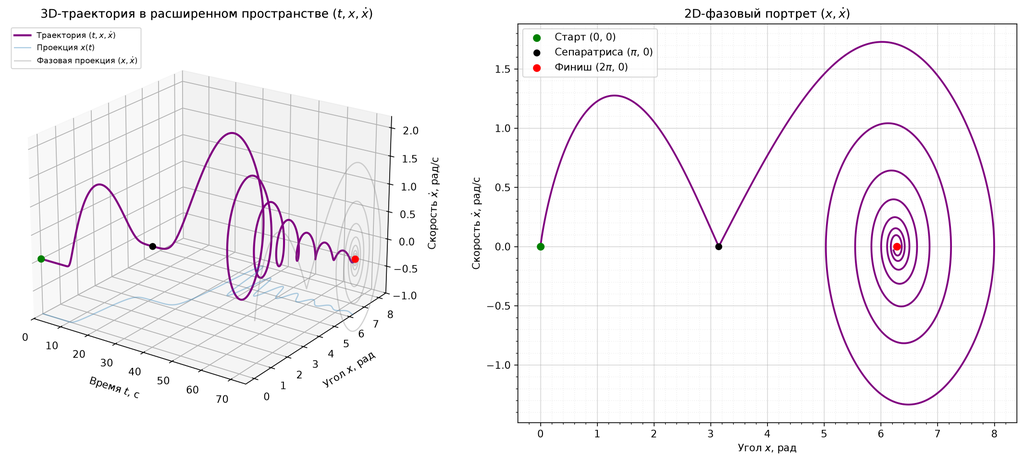

## Задание 2. Нелинейный математический маятник

Рассматривается модель нелинейного математического маятника с затуханием: \begin{equation*} \ddot{x} + 0.1\dot{x} + \sin(x) = F(t) \end{equation*} с точными нулевыми начальными условиями $x(0) = 0$, $\dot{x}(0) = 0$, где $x(t)$ - угол отклонения маятника от нижнего положения равновесия в радианах.

Сконструируйте в явном аналитическом виде внешнее воздействие $F(t)$, которое переводит маятник из нижнего устойчивого положения равновесия $x = 0$ в верхнее неустойчивое положение равновесия $x = \pi$ и полностью останавливает его в этой точке.

### Требования к системе и управлению:

- Начальный покой: в течение первых $10$ секунд маятник должен оставаться в состоянии, близком к покою ($|x(t)| < 10^{-4}$ рад).
- Асимптотическая стабилизация наверху: при $t \to +\infty$ система должна стремиться к верхнему положению равновесия без колебаний и перелётов: \begin{equation*} \lim_{t \to +\infty} x(t) = \pi, \qquad \lim_{t \to +\infty} \dot{x}(t) = 0, \qquad 0 \le x(t) < \pi \quad \forall t \ge 0. \end{equation*}
- Достижение цели за конечное время: к моменту времени $t = 30$ с маятник должен находиться в окрестности верхней точки ($|x(t) - \pi| < 10^{-3}$ рад и $|\dot{x}(t)| < 10^{-3}$ рад/с при всех $t \ge 30$ с).
- Аналитичность: внешнее воздействие $F(t)$ должно зависеть только от времени $t$ (не зависеть от фазовых координат $x, \dot{x}$) и принадлежать классу вещественно-аналитических функций $C^{\omega}(\mathbb{R})$.

### Задание:

- Запишите явную аналитическую формулу для $F(t)$ (используя элементарные функции) и аналитически докажите выполнение условий $x(0)=0$, $\dot{x}(0)=0$ и предельных соотношений при $t \to +\infty$.
- Постройте графики $F(t)$, $x(t)$ и $\dot{x}(t)$ на интервале $t \in [0, 40]$ с и проверьте поведение решения при численном интегрировании уравнения с найденной функцией $F(t)$ на интервале $t \in [0, 60]$ с (прокомментируйте эффект численной неустойчивости седловой точки при больших $t$).